# Part I - (Ford GoBike System Data Exploration)

## Introduction

> The dataset contains information about individual rides made in the Ford GoBike bike-sharing system covering the greater San Fransisco Bay area

## Preliminary Wrangling

```python
# import all packages and set plots to be embedded inline
import numpy as np
import pandas as pd
import matplotlib.pyplot as plt
import seaborn as sb

%matplotlib inline
```

```python
#loading dataset
bike_trips = pd.read_csv("201902-fordgobike-tripdata.csv")
bike_trips.head()
```

|  | duration_sec | start_time | end_time | start_station_id | start_station_name | start_station_latitude | start_station_longitude | end_station_id | end_station_name | end_station_latitude | end_station_longitude | bike_id | user_type | member_birth_year | member_gender | bike_share_for_all_trip |
| --- | --- | --- | --- | --- | --- | --- | --- | --- | --- | --- | --- | --- | --- | --- | --- | --- |
| 0 | 52185 | 2019-02-28 17:32:10.1450 | 2019-03-01 08:01:55.9750 | 21.0 | Montgomery St BART Station (Market St at 2nd St) | 37.789625 | -122.400811 | 13.0 | Commercial St at Montgomery St | 37.794231 | -122.402923 | 4902 | Customer | 1984.0 | Male | No |
| 1 | 42521 | 2019-02-28 18:53:21.7890 | 2019-03-01 06:42:03.0560 | 23.0 | The Embarcadero at Steuart St | 37.791464 | -122.391034 | 81.0 | Berry St at 4th St | 37.775880 | -122.393170 | 2535 | Customer | NaN | NaN | No |
| 2 | 61854 | 2019-02-28 12:13:13.2180 | 2019-03-01 05:24:08.1460 | 86.0 | Market St at Dolores St | 37.769305 | -122.426826 | 3.0 | Powell St BART Station (Market St at 4th St) | 37.786375 | -122.404904 | 5905 | Customer | 1972.0 | Male | No |
| 3 | 36490 | 2019-02-28 17:54:26.0100 | 2019-03-01 04:02:36.8420 | 375.0 | Grove St at Masonic Ave | 37.774836 | -122.446546 | 70.0 | Central Ave at Fell St | 37.773311 | -122.444293 | 6638 | Subscriber | 1989.0 | Other | No |
| 4 | 1585 | 2019-02-28 23:54:18.5490 | 2019-03-01 00:20:44.0740 | 7.0 | Frank H Ogawa Plaza | 37.804562 | -122.271738 | 222.0 | 10th Ave at E 15th St | 37.792714 | -122.248780 | 4898 | Subscriber | 1974.0 | Male | Yes |

```python
print(bike_trips.shape)
print(bike_trips.dtypes)
```

```
(183412, 16)
duration_sec                 int64
start_time                  object
end_time                    object
start_station_id           float64
start_station_name          object
start_station_latitude     float64
start_station_longitude    float64
end_station_id             float64
end_station_name            object
end_station_latitude       float64
end_station_longitude      float64
bike_id                      int64
user_type                   object
member_birth_year          float64
member_gender               object
bike_share_for_all_trip     object
dtype: object
```

```python
# convert user_type and member_gender into categorical variables.
nominal_var_dict = {'user_type': ['Subscriber','Customer'],
                    'member_gender': ['Male', 'Female', 'Other'],
                   'bike_share_for_all_trip': ['No', 'Yes']}

for var in nominal_var_dict:
    unordered_var = pd.api.types.CategoricalDtype(ordered = False,
                                                categories = nominal_var_dict[var])
    bike_trips[var] = bike_trips[var].astype(unordered_var)
```

```python
# Changing the format to datetime
bike_trips['start_time'] = pd.to_datetime(bike_trips['start_time'])
bike_trips['end_time'] = pd.to_datetime(bike_trips['end_time'])
bike_trips.dtypes
```

```
duration_sec                        int64
start_time                 datetime64[ns]
end_time                   datetime64[ns]
start_station_id                  float64
start_station_name                 object
start_station_latitude            float64
start_station_longitude           float64
end_station_id                    float64
end_station_name                   object
end_station_latitude              float64
end_station_longitude             float64
bike_id                             int64
user_type                        category
member_birth_year                 float64
member_gender                    category
bike_share_for_all_trip          category
dtype: object
```

```python
#extracting day and hour from startdate column
bike_trips['start_time_weekday'] = bike_trips['start_time'].dt.strftime('%A')
bike_trips['start_time_hour'] = bike_trips['start_time'].dt.hour
bike_trips.head()
```

|  | duration_sec | start_time | end_time | start_station_id | start_station_name | start_station_latitude | start_station_longitude | end_station_id | end_station_name | end_station_latitude | end_station_longitude | bike_id | user_type | member_birth_year | member_gender | bike_share_for_all_trip | start_time_weekday | start_time_hour |
| --- | --- | --- | --- | --- | --- | --- | --- | --- | --- | --- | --- | --- | --- | --- | --- | --- | --- | --- |
| 0 | 52185 | 2019-02-28 17:32:10.145 | 2019-03-01 08:01:55.975 | 21.0 | Montgomery St BART Station (Market St at 2nd St) | 37.789625 | -122.400811 | 13.0 | Commercial St at Montgomery St | 37.794231 | -122.402923 | 4902 | Customer | 1984.0 | Male | No | Thursday | 17 |
| 1 | 42521 | 2019-02-28 18:53:21.789 | 2019-03-01 06:42:03.056 | 23.0 | The Embarcadero at Steuart St | 37.791464 | -122.391034 | 81.0 | Berry St at 4th St | 37.775880 | -122.393170 | 2535 | Customer | NaN | NaN | No | Thursday | 18 |
| 2 | 61854 | 2019-02-28 12:13:13.218 | 2019-03-01 05:24:08.146 | 86.0 | Market St at Dolores St | 37.769305 | -122.426826 | 3.0 | Powell St BART Station (Market St at 4th St) | 37.786375 | -122.404904 | 5905 | Customer | 1972.0 | Male | No | Thursday | 12 |
| 3 | 36490 | 2019-02-28 17:54:26.010 | 2019-03-01 04:02:36.842 | 375.0 | Grove St at Masonic Ave | 37.774836 | -122.446546 | 70.0 | Central Ave at Fell St | 37.773311 | -122.444293 | 6638 | Subscriber | 1989.0 | Other | No | Thursday | 17 |
| 4 | 1585 | 2019-02-28 23:54:18.549 | 2019-03-01 00:20:44.074 | 7.0 | Frank H Ogawa Plaza | 37.804562 | -122.271738 | 222.0 | 10th Ave at E 15th St | 37.792714 | -122.248780 | 4898 | Subscriber | 1974.0 | Male | Yes | Thursday | 23 |

```python
#It is import to know the age of the users in order to
#get insights on the target audience.
bike_trips['age'] = 2019 - bike_trips['member_birth_year']
bike_trips.head()
```

|  | duration_sec | start_time | end_time | start_station_id | start_station_name | start_station_latitude | start_station_longitude | end_station_id | end_station_name | end_station_latitude | end_station_longitude | bike_id | user_type | member_birth_year | member_gender | bike_share_for_all_trip | start_time_weekday | start_time_hour | age |
| --- | --- | --- | --- | --- | --- | --- | --- | --- | --- | --- | --- | --- | --- | --- | --- | --- | --- | --- | --- |
| 0 | 52185 | 2019-02-28 17:32:10.145 | 2019-03-01 08:01:55.975 | 21.0 | Montgomery St BART Station (Market St at 2nd St) | 37.789625 | -122.400811 | 13.0 | Commercial St at Montgomery St | 37.794231 | -122.402923 | 4902 | Customer | 1984.0 | Male | No | Thursday | 17 | 35.0 |
| 1 | 42521 | 2019-02-28 18:53:21.789 | 2019-03-01 06:42:03.056 | 23.0 | The Embarcadero at Steuart St | 37.791464 | -122.391034 | 81.0 | Berry St at 4th St | 37.775880 | -122.393170 | 2535 | Customer | NaN | NaN | No | Thursday | 18 | NaN |
| 2 | 61854 | 2019-02-28 12:13:13.218 | 2019-03-01 05:24:08.146 | 86.0 | Market St at Dolores St | 37.769305 | -122.426826 | 3.0 | Powell St BART Station (Market St at 4th St) | 37.786375 | -122.404904 | 5905 | Customer | 1972.0 | Male | No | Thursday | 12 | 47.0 |
| 3 | 36490 | 2019-02-28 17:54:26.010 | 2019-03-01 04:02:36.842 | 375.0 | Grove St at Masonic Ave | 37.774836 | -122.446546 | 70.0 | Central Ave at Fell St | 37.773311 | -122.444293 | 6638 | Subscriber | 1989.0 | Other | No | Thursday | 17 | 30.0 |
| 4 | 1585 | 2019-02-28 23:54:18.549 | 2019-03-01 00:20:44.074 | 7.0 | Frank H Ogawa Plaza | 37.804562 | -122.271738 | 222.0 | 10th Ave at E 15th St | 37.792714 | -122.248780 | 4898 | Subscriber | 1974.0 | Male | Yes | Thursday | 23 | 45.0 |

```python
#converting duration from seconds to minutes
bike_trips['duration_min'] = round(bike_trips['duration_sec']/60, 2)
bike_trips.head()
```

|  | duration_sec | start_time | end_time | start_station_id | start_station_name | start_station_latitude | start_station_longitude | end_station_id | end_station_name | end_station_latitude | end_station_longitude | bike_id | user_type | member_birth_year | member_gender | bike_share_for_all_trip | start_time_weekday | start_time_hour | age | duration_min |
| --- | --- | --- | --- | --- | --- | --- | --- | --- | --- | --- | --- | --- | --- | --- | --- | --- | --- | --- | --- | --- |
| 0 | 52185 | 2019-02-28 17:32:10.145 | 2019-03-01 08:01:55.975 | 21.0 | Montgomery St BART Station (Market St at 2nd St) | 37.789625 | -122.400811 | 13.0 | Commercial St at Montgomery St | 37.794231 | -122.402923 | 4902 | Customer | 1984.0 | Male | No | Thursday | 17 | 35.0 | 869.75 |
| 1 | 42521 | 2019-02-28 18:53:21.789 | 2019-03-01 06:42:03.056 | 23.0 | The Embarcadero at Steuart St | 37.791464 | -122.391034 | 81.0 | Berry St at 4th St | 37.775880 | -122.393170 | 2535 | Customer | NaN | NaN | No | Thursday | 18 | NaN | 708.68 |
| 2 | 61854 | 2019-02-28 12:13:13.218 | 2019-03-01 05:24:08.146 | 86.0 | Market St at Dolores St | 37.769305 | -122.426826 | 3.0 | Powell St BART Station (Market St at 4th St) | 37.786375 | -122.404904 | 5905 | Customer | 1972.0 | Male | No | Thursday | 12 | 47.0 | 1030.90 |
| 3 | 36490 | 2019-02-28 17:54:26.010 | 2019-03-01 04:02:36.842 | 375.0 | Grove St at Masonic Ave | 37.774836 | -122.446546 | 70.0 | Central Ave at Fell St | 37.773311 | -122.444293 | 6638 | Subscriber | 1989.0 | Other | No | Thursday | 17 | 30.0 | 608.17 |
| 4 | 1585 | 2019-02-28 23:54:18.549 | 2019-03-01 00:20:44.074 | 7.0 | Frank H Ogawa Plaza | 37.804562 | -122.271738 | 222.0 | 10th Ave at E 15th St | 37.792714 | -122.248780 | 4898 | Subscriber | 1974.0 | Male | Yes | Thursday | 23 | 45.0 | 26.42 |

```python
pd.set_option('display.max_colwidth', -1)
bike_trips['route'] = bike_trips['start_station_name'] + ' to ' + bike_trips['end_station_name']
bike_trips.head()
```

|  | duration_sec | start_time | end_time | start_station_id | start_station_name | start_station_latitude | start_station_longitude | end_station_id | end_station_name | end_station_latitude | ... | bike_id | user_type | member_birth_year | member_gender | bike_share_for_all_trip | start_time_weekday | start_time_hour | age | duration_min | route |
| --- | --- | --- | --- | --- | --- | --- | --- | --- | --- | --- | --- | --- | --- | --- | --- | --- | --- | --- | --- | --- | --- |
| 0 | 52185 | 2019-02-28 17:32:10.145 | 2019-03-01 08:01:55.975 | 21.0 | Montgomery St BART Station (Market St at 2nd St) | 37.789625 | -122.400811 | 13.0 | Commercial St at Montgomery St | 37.794231 | ... | 4902 | Customer | 1984.0 | Male | No | Thursday | 17 | 35.0 | 869.75 | Montgomery St BART Station (Market St at 2nd St) to Commercial St at Montgomery St |
| 1 | 42521 | 2019-02-28 18:53:21.789 | 2019-03-01 06:42:03.056 | 23.0 | The Embarcadero at Steuart St | 37.791464 | -122.391034 | 81.0 | Berry St at 4th St | 37.775880 | ... | 2535 | Customer | NaN | NaN | No | Thursday | 18 | NaN | 708.68 | The Embarcadero at Steuart St to Berry St at 4th St |
| 2 | 61854 | 2019-02-28 12:13:13.218 | 2019-03-01 05:24:08.146 | 86.0 | Market St at Dolores St | 37.769305 | -122.426826 | 3.0 | Powell St BART Station (Market St at 4th St) | 37.786375 | ... | 5905 | Customer | 1972.0 | Male | No | Thursday | 12 | 47.0 | 1030.90 | Market St at Dolores St to Powell St BART Station (Market St at 4th St) |
| 3 | 36490 | 2019-02-28 17:54:26.010 | 2019-03-01 04:02:36.842 | 375.0 | Grove St at Masonic Ave | 37.774836 | -122.446546 | 70.0 | Central Ave at Fell St | 37.773311 | ... | 6638 | Subscriber | 1989.0 | Other | No | Thursday | 17 | 30.0 | 608.17 | Grove St at Masonic Ave to Central Ave at Fell St |
| 4 | 1585 | 2019-02-28 23:54:18.549 | 2019-03-01 00:20:44.074 | 7.0 | Frank H Ogawa Plaza | 37.804562 | -122.271738 | 222.0 | 10th Ave at E 15th St | 37.792714 | ... | 4898 | Subscriber | 1974.0 | Male | Yes | Thursday | 23 | 45.0 | 26.42 | Frank H Ogawa Plaza to 10th Ave at E 15th St |

5 rows × 21 columns

### What is the structure of your dataset?

> There are 183, 412 individual bike trips in the dataset with 16 features which inciude: duration_sec, start_time, end_time, end_time, start_station_id, start_station_nam, start_station_latitude start_station_longitude end_station_id end_station_name end_station_latitude end_station_longitude, bike_id, user_type, member_birth_year, member_gender, bike_share_for_all_trip

### What is/are the main feature(s) of interest in your dataset?

> I am most interested in features that can give me insights on the demands of bike rides and discovering trends in bike usage in the dataset.

### What features in the dataset do you think will help support your investigation into your feature(s) of interest?

> I expect types of users, start_time and duration to give me insights on bike usage trends.

## Univariate Exploration

### We are going to start by exploration the distribution of the trip duration in minutes

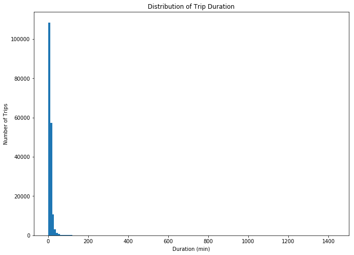

```python
#Getting ticks for bins
bins = np.arange(0, bike_trips['duration_min'].max() + 10, 10)

#plot histogram
plt.figure(figsize=[11, 8])
plt.hist(data = bike_trips, x = 'duration_min', bins = bins)
plt.xlabel('Duration (min)')
plt.ylabel('Number of Trips')
plt.title('Distribution of Trip Duration');
```

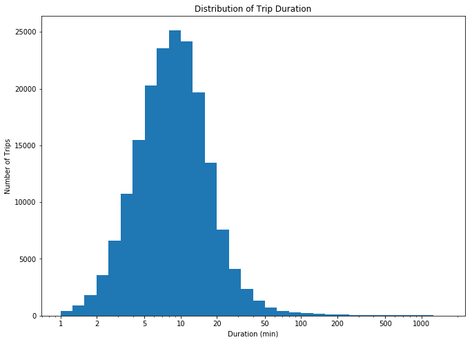

```python
#there is a long tail in the distribution, so let's put it on a log scale instead

# Get the ticks for bins between [0 - maximum duration]
bins1 = 10 ** np.arange(0, np.log10(bike_trips['duration_min'].max()) + 0.1, 0.1)

ticks = [1, 2, 5, 10, 20, 50, 100, 200, 500, 1000]
# Convert ticks into string values, to be displaye dlong the x-axis
labels = ['{}'.format(v) for v in ticks]

#plot the histogram
plt.figure(figsize=[11, 8])
plt.hist(data = bike_trips, x = 'duration_min', bins = bins1);
plt.xlabel('Duration (min)')
plt.ylabel('Number of Trips')
plt.title('Distribution of Trip Duration')

#applying a log scale to the x-axis
plt.xscale('log')

# Apply x-ticks
plt.xticks(ticks, labels);
```

Trip duration has a long tailed distribution and when converted to log scale the didtribution is unimodal and fairy symmetric with a top peak between 8 and 10 minutes. Most of the bike rides were less than 30 minutes.

**Next we are going to investigate the type of Gobike users. A customer is a user who holds a single-ride or day pass while a subscriber has a monthly or annual pass.**

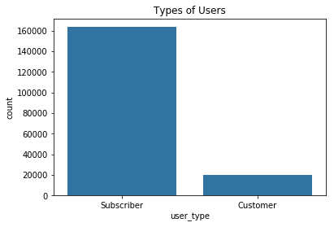

```python
base_color = sb.color_palette()[0]

sb.countplot(data = bike_trips, x = 'user_type', color = base_color)
plt.title('Types of Users');
```

Clearly majority of the users are subscribers.

### I will also investage the gender distribution as show below.

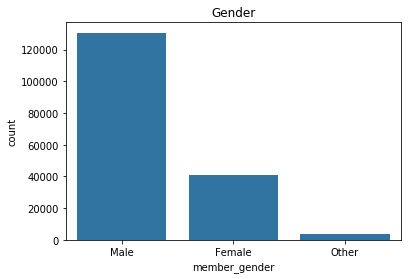

```python
base_color = sb.color_palette()[0]

sb.countplot(data = bike_trips, x = 'member_gender', color = base_color)
plt.title('Gender');
```

### I am also going to investigate the distribution of the age of users.

```python
bike_trips['age'].describe()
```

```
count    175147.000000
mean     34.193563
std      10.116689
min      18.000000
25%      27.000000
50%      32.000000
75%      39.000000
max      141.000000
Name: age, dtype: float64
```

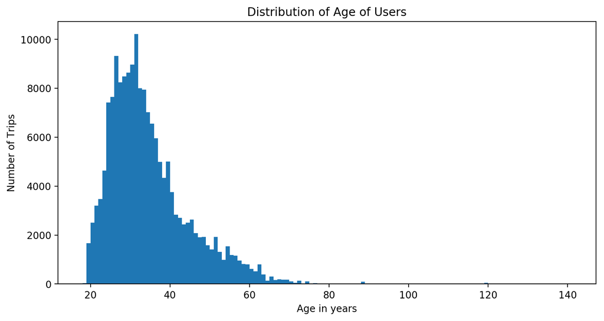

```python
plt.figure(figsize = (10,5), dpi = 200)
bins = np.arange(18, bike_trips['age'].max()+1, 1)

plt.hist(data = bike_trips.dropna(), x = 'age', bins = bins)
plt.xlabel('Age in years')
plt.ylabel('Number of Trips')
plt.title('Distribution of Age of Users');
```

The distribution indicates that most users are between the age 25 and 35 and the number of users steadily decrease from ages 40 onwards. However we need to investigate the validity of ages since the eldest user is 141 years which is questionable. We will use a boxplot to check for outliers in the Age distribution.

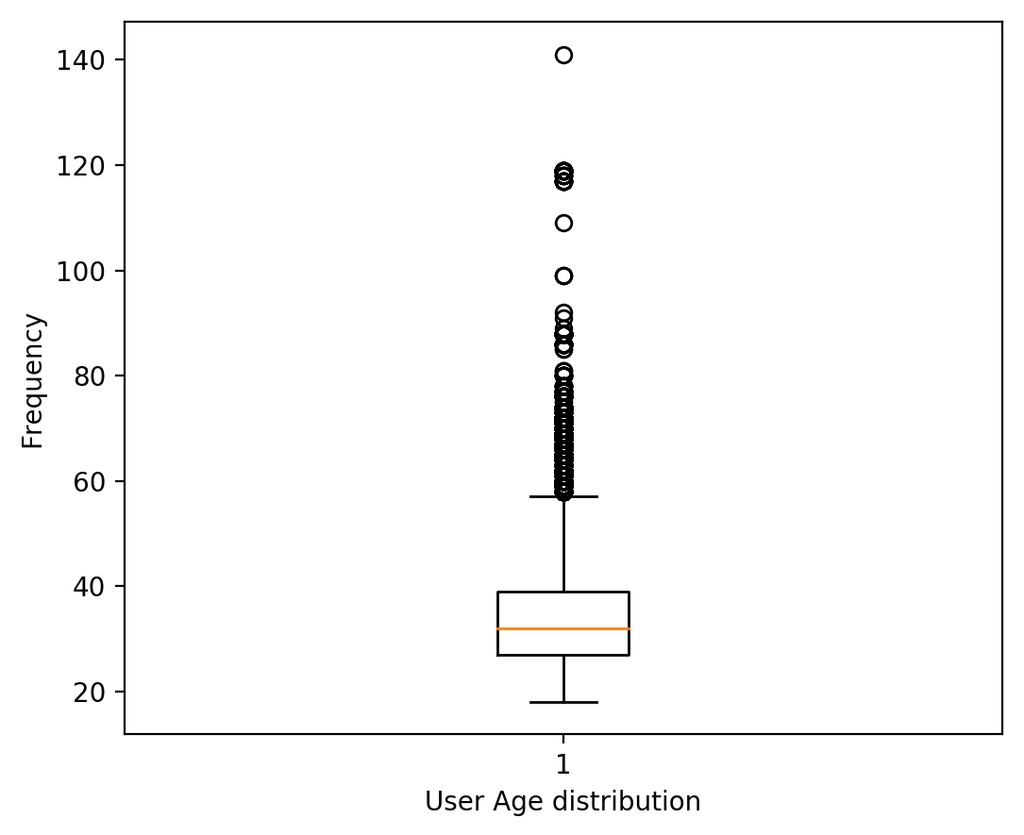

```python
#checking for outliers in Age variable
plt.figure(figsize = (6,5), dpi = 200)

#plotting boxplot
plt.boxplot(data = bike_trips.dropna(), x = 'age', vert=True)

plt.xlabel('User Age distribution')
plt.ylabel('Frequency')
plt.title("");
```

I can actually confirm there are some outliers but they are few so I will just leave them be and may be do some further investigation if there were errors when imputting member birth year. Otherwise, they don't really affect my analysis as much.

**Next we will investigate the average number of trips made on different days of the week.**

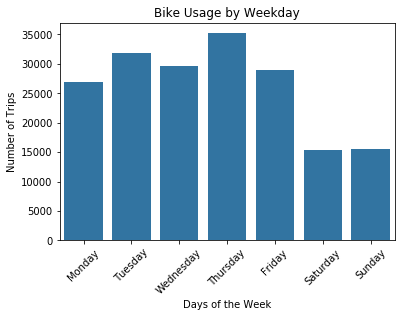

```python
days = ['Monday', 'Tuesday', 'Wednesday', 'Thursday', 'Friday', 'Saturday', 'Sunday']
sb.countplot(data = bike_trips, x = 'start_time_weekday', color = base_color, order = days)
plt.xticks(rotation = 45)
plt.xlabel('Days of the Week')
plt.ylabel('Number of Trips')
plt.title('Bike Usage by Weekday');
```

We can observe there are generally more bike rides from Monday to Friday than during the weekends that is Saturday and Sunday.

**I was also interested in investigating bike usage by hour.**

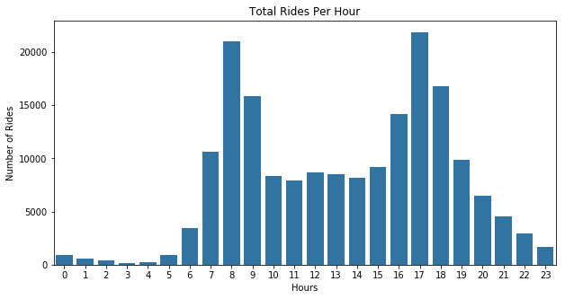

```python
hours = np.arange(0, 24, 1)


plt.figure(figsize = (10,5))
#use a countplot because hours are discrete
sb.countplot(data = bike_trips, x = 'start_time_hour', order = hours, color = base_color);
plt.xlabel('Hours')
plt.ylabel('Number of Rides')
plt.title('Total Rides Per Hour');
```

A bimodal distribution can be observed with two peaks at 8am and 5pm. This may because they are commute hours and hence the busiest time of the day. We can also observe that the least number of rides are made between 1am and 4am which is when most people are asleep.

**Finally I was also interested in investigating the most popular routes during a bike ride.**

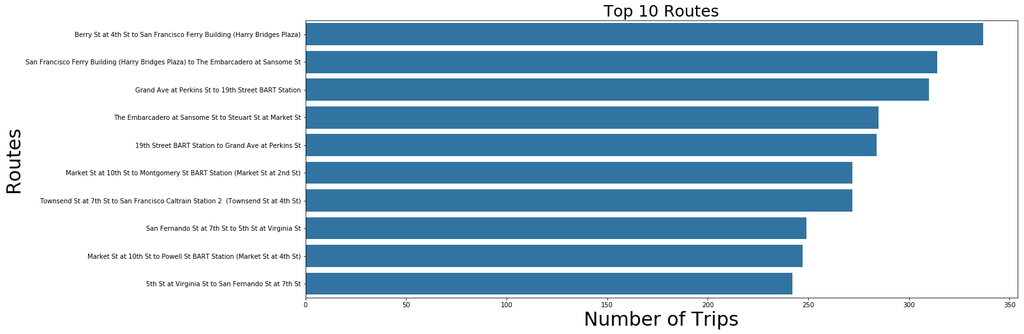

```python
plt.figure(figsize = (20,8))
ax = sb.barplot(y = bike_trips['route'].value_counts()[0:10].index,
            x = bike_trips['route'].value_counts()[0:10],
            data = bike_trips, color = base_color);
plt.xlabel("Number of Trips",fontsize = 30);
plt.ylabel("Routes",fontsize = 30);
plt.title("Top 10 Routes",fontsize = 25);
```

We can clearly see the most popular biking routes with `Berry St at 4th St to Sanfransisco Ferry Building` taking the lead. This is very useful information which can be used to decide on the number of bikes to avail at each station.

### Discuss the distribution(s) of your variable(s) of interest. Were there any unusual points? Did you need to perform any transformations?

The duration variable in minutes took on a large range of values, so I looked at the data using a log transform. Under the transformation, the data looked unimodal, with one peak between 8 and 10 minutes.

### Of the features you investigated, were there any unusual distributions? Did you perform any operations on the data to tidy, adjust, or change the form of the data? If so, why did you do this?

When investigating the duration_sec we had to convert it to minutes by dividing by 60 and to get the age of the users I had to subtract `member_birth_year` from the year the dataset was collected which is 2019. The were also some few outliers in the newly created Age variable. I also needed to create a new variable `route` by concatinating `start_station_name` and `end_station_name` so that I can investigate the most popular routes.

## Bivariate Exploration

**First thing I am curious about is which type of users spends more time during their bike rides.**

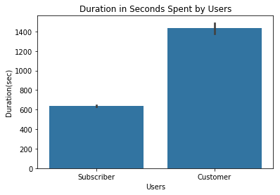

```python
sb.barplot(data = bike_trips, x = 'user_type', y = 'duration_sec', color = base_color)
plt.title('Duration in Seconds Spent by Users')
plt.xlabel('Users')
plt.ylabel('Duration(sec)');
```

Customers actually spend more time during their rides than subscribers.

**I also investigated if the is a relationship between age of users and duration of bike trips.**

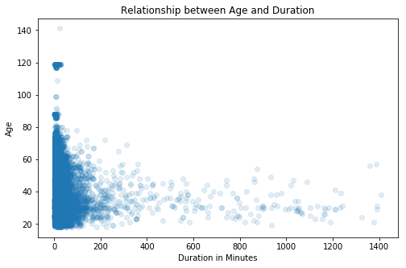

```python
plt.figure(figsize = (8,5))
plt.scatter(data = bike_trips, y = 'age', x = 'duration_min', alpha = 1/8);
plt.title('Relationship between Age and Duration')
plt.xlabel('Duration in Minutes')
plt.ylabel('Age');
```

It can be observed users of all ages tend to have bike trips which less than 200 minutes.

**Next up I want to investigate the distribution of start hour of bike trips with respect to type of user.**

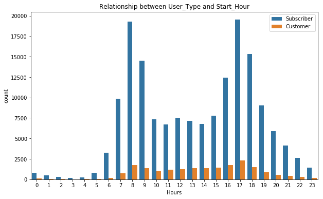

```python
plt.figure(figsize = (10,6))
sb.countplot(data = bike_trips, x = 'start_time_hour', hue = 'user_type')
plt.xlabel('Hours');
plt.title('Relationship between User_Type and Start_Hour')
plt.legend();
```

Generally subscribers take more bike rides compared to customers especially during commuting hours.

**It is also important I investigate the trends in usage of bikes along the week.**

```python
bike_trips_sub = bike_trips.groupby(['start_time_weekday', 'user_type']).size().reset_index()
bike_trips_sub
```

|  | start_time_weekday | user_type | 0 |
| --- | --- | --- | --- |
| 0 | Friday | Subscriber | 25951 |
| 1 | Friday | Customer | 3030 |
| 2 | Monday | Subscriber | 24111 |
| 3 | Monday | Customer | 2741 |
| 4 | Saturday | Subscriber | 12666 |
| 5 | Saturday | Customer | 2739 |
| 6 | Sunday | Subscriber | 12627 |
| 7 | Sunday | Customer | 2896 |
| 8 | Thursday | Subscriber | 31807 |
| 9 | Thursday | Customer | 3390 |
| 10 | Tuesday | Subscriber | 29207 |
| 11 | Tuesday | Customer | 2606 |
| 12 | Wednesday | Subscriber | 27175 |
| 13 | Wednesday | Customer | 2466 |

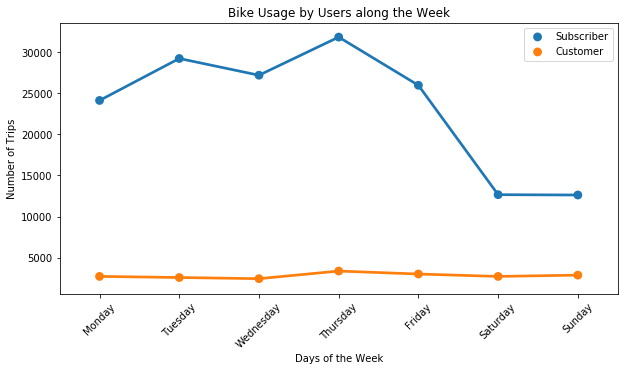

```python
plt.figure(figsize = (10,5))
sb.pointplot(data = bike_trips_sub, x = 'start_time_weekday', y = 0,hue = 'user_type', order = days)
plt.xticks(rotation = 45)
plt.legend()
plt.xlabel('Days of the Week')
plt.ylabel('Number of Trips')
plt.title('Bike Usage by Users along the Week');
```

Clearly subscribers use the bike sharing system more than customers along the week. Customers have a relatively consistent bike trips along the week while we can observe a big decrease in bike trips during the weekend for subscribers.

### Talk about some of the relationships you observed in this part of the investigation. How did the feature(s) of interest vary with other features in the dataset?

> I was interested in knowing which users take more rides at different hours of the day and during different days of the week. Turns out subscribers take significantly more bike rides than customers. I also investigated if the age of a user had any influence on the duration of bike ride. The conclusion was that that users of all ages take bike rides that are less than 200 minutes. Furthermore, when investigating which type of users take longer bike rides, it was suprising to seee that customers actually take longer bike rides than subscribers.

## Multivariate Exploration

**First thing I would like to investigate is the bike ride duration along the week with respect to different user genders.**

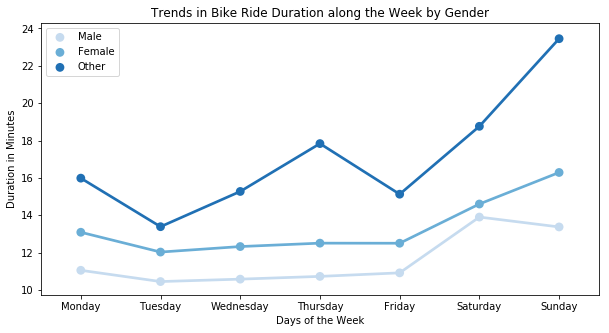

```python
plt.figure(figsize = (10,5))
sb.pointplot(data = bike_trips, x = 'start_time_weekday', y = 'duration_min', hue = 'member_gender', palette = 'Blues', ci=None, order = days)
plt.legend()
plt.xlabel('Days of the Week')
plt.ylabel('Duration in Minutes')
plt.title('Trends in Bike Ride Duration along the Week by Gender');
```

We can observe that females take longer bike rides along the week compared to male users.

**Another thing I was curious about is whick types of users take longer bike rides along the week.**

[figure not shown]

```python
plt.figure(figsize = (10,5))
sb.pointplot(data = bike_trips, x = 'start_time_weekday', y = 'duration_min', hue = 'user_type', ci=None, order = days)
plt.legend()
plt.xlabel('Days of the Week')
plt.ylabel('Duration in Minutes')
plt.title('Trends in Bike Ride Duration along the Week by Gender');
```

Customers take longer bike rides than subscribers throughout the week. However, in both cases the duration of bike rides increased during the weekends.

### Talk about some of the relationships you observed in this part of the investigation. Were there features that strengthened each other in terms of looking at your feature(s) of interest?

> At the beginning of the analysis my main goal was to understand the trends in bike usage among different users. Consequently, I investigated the relationship between trip duration and gender of user along the week. The pointplot shows female riders takes longer rides than male riders. Next it was also import to investigate who take longer bike rides along the week, subscribers or customers. Customers take longer bike rides throughtout the week.

### Were there any interesting or surprising interactions between features?

> Yes, I actually thought male bike riders would take longer bike rides than female bike riders throughtout the week because there were more male users which turned out to be false. Another interesting insight was there was increase in bike duration during the weekends in both user types considering the number of bike rides during the weekends were decreasing as seen earlier.

## Conclusions

> The analysis was very insightful and some extra effort had to be put in to ensure the variables of interest had the correct datatype and I also had to extract some variables from the start_time variable to make my analysis comprehensive. Some feature engineering had to performed also to get the age of the users. Subsequently, this are my main insights:
1. Customers make longer bike rides.
2. There is a spike in bike rides during commute hours.
3. There are fewer bike rides during the weekends however they are longer than other days of the week
4. There are more male riders than female riders. However, female riders take longer bike rides than male riders.